# Wing chord ~ age

Casey Youngflesh

### Purpose

Investigate changes in wing chord over the lifespan of birds.

### Database query

Day between 100 and 300 Only capture code ‘N’, ‘R’, ‘U’ (new, recaptures, unbanded birds)

### Data processing

Fill true age for each bird for each year. Done using birth year derived from birds either caught during the hatch year or birds listed as Second Year Bird. Remove all 0 values for weight and wing_chord. Filter to only known age adults (greater than 1 year old AKA Second Year or later).

For each individual band_id, take mean wing_chord for Age 1 (Second Year) and mean wing chord for Age 2+ (Third Year +); also calculate wing_chord coefficient of variation (sd/mean) Age 1 and Age 2+. Remove any individuals that have Age 1 CV of greater than 0.03 and Age 2+ CV of greater than 0.05 (sds that are greater than 3% and 5% of mean, respectively).

### Analysis

Run paired two-tailed t-test for each species that had measurements for more than 20 individuals (to test difference in wing_chord between Age 1 and Age 2+ age classes). Estimated difference and corrected p-values returned for each species. There are likely better ways to analyze these data, but this was relatively straightforward and easy.

### Results

Wing chord increase from Age 1 (Second Year) to Age 2+ (Third Year+). This holds true across most species analyzed.

| scientific name | common name | difference | corrected p-value |
| --- | --- | --- | --- |
| Melospiza melodia | Song Sparrow | -1.069 | 0.000 |
| Spizella pallida | Clay-colored Sparrow | -0.845 | 0.035 |
| Catharus ustulatus | Swainson’s Thrush | -2.194 | 0.000 |
| Setophaga ruticilla | American Redstart | -1.613 | 0.000 |
| Melospiza lincolnii | Lincoln’s Sparrow | -1.246 | 0.000 |
| Catharus guttatus | Hermit Thrush | -1.597 | 0.000 |
| Setophaga petechia | Yellow Warbler | -1.155 | 0.000 |
| Empidonax minimus | Least Flycatcher | -1.138 | 0.000 |
| Cardellina pusilla | Wilson’s Warbler | -1.006 | 0.000 |
| Geothlypis trichas | Common Yellowthroat | -1.493 | 0.000 |
| Turdus migratorius | American Robin | -2.158 | 0.001 |
| Setophaga magnolia | Magnolia Warbler | -1.260 | 0.000 |
| Cardellina canadensis | Canada Warbler | -0.760 | 0.002 |
| Dryobates pubescens | Downy Woodpecker | -0.970 | 0.011 |
| Zonotrichia albicollis | White-throated Sparrow | -1.219 | 0.000 |
| Poecile atricapillus | Black-capped Chickadee | -0.864 | 0.000 |
| Spizella passerina | Chipping Sparrow | -1.229 | 0.002 |
| Seiurus aurocapilla | Ovenbird | -1.804 | 0.000 |
| Mniotilta varia | Black-and-white Warbler | -1.220 | 0.001 |
| Oreothlypis celata | Orange-crowned Warbler | -1.006 | 0.006 |
| Hylocichla mustelina | Wood Thrush | -1.668 | 0.000 |
| Empidonax virescens | Acadian Flycatcher | -1.425 | 0.000 |
| Thryothorus ludovicianus | Carolina Wren | -0.499 | 0.003 |
| Geothlypis formosa | Kentucky Warbler | -1.392 | 0.000 |
| Passerina cyanea | Indigo Bunting | -0.700 | 0.000 |
| Icteria virens | Yellow-breasted Chat | -1.485 | 0.000 |
| Setophaga citrina | Hooded Warbler | -1.547 | 0.000 |
| Baeolophus bicolor | Tufted Titmouse | -1.848 | 0.001 |
| Vireo griseus | White-eyed Vireo | -1.045 | 0.000 |
| Pipilo erythrophthalmus | Eastern Towhee | -3.151 | 0.000 |
| Spizella pusilla | Field Sparrow | -1.057 | 0.001 |
| Dumetella carolinensis | Gray Catbird | -2.712 | 0.000 |
| Spinus tristis | American Goldfinch | -1.343 | 0.000 |
| Cardinalis cardinalis | Northern Cardinal | -1.351 | 0.000 |
| Protonotaria citrea | Prothonotary Warbler | -1.458 | 0.000 |
| Passerina ciris | Painted Bunting | -1.113 | 0.000 |
| Vermivora cyanoptera | Blue-winged Warbler | -1.424 | 0.000 |
| Piranga rubra | Summer Tanager | -2.062 | 0.000 |
| Setophaga pensylvanica | Chestnut-sided Warbler | -1.211 | 0.000 |
| Catharus fuscescens | Veery | -2.359 | 0.000 |
| Troglodytes aedon | House Wren | -1.102 | 0.000 |
| Thryomanes bewickii | Bewick’s Wren | -0.972 | 0.000 |
| Vireo gilvus | Warbling Vireo | -0.832 | 0.003 |
| Pipilo maculatus | Spotted Towhee | -2.362 | 0.000 |
| Empidonax traillii | Willow Flycatcher | -0.065 | 0.836 |
| Pheucticus melanocephalus | Black-headed Grosbeak | -1.862 | 0.000 |
| Chamaea fasciata | Wrentit | -0.321 | 0.597 |
| Poecile rufescens | Chestnut-backed Chickadee | -1.634 | 0.000 |
| Haemorhous purpureus | Purple Finch | -1.880 | 0.000 |
| Empidonax difficilis | Pacific-slope Flycatcher | -1.973 | 0.000 |
| Junco heymalis oreganus | Oregon Junco | -1.734 | 0.000 |
| Geothlypis tolmiei | MacGillivray’s Warbler | -1.575 | 0.000 |

Table 1: Results from t-tests. Estimated differences in wing chord (in mm) between Age 1 (Second Year) and Age 2+ (Third Year +) birds and Benjamini & Hochberg adjusted p-values (multiple comparison correction). Negative values for differences in wing chord represent an increase in wing chord with age.

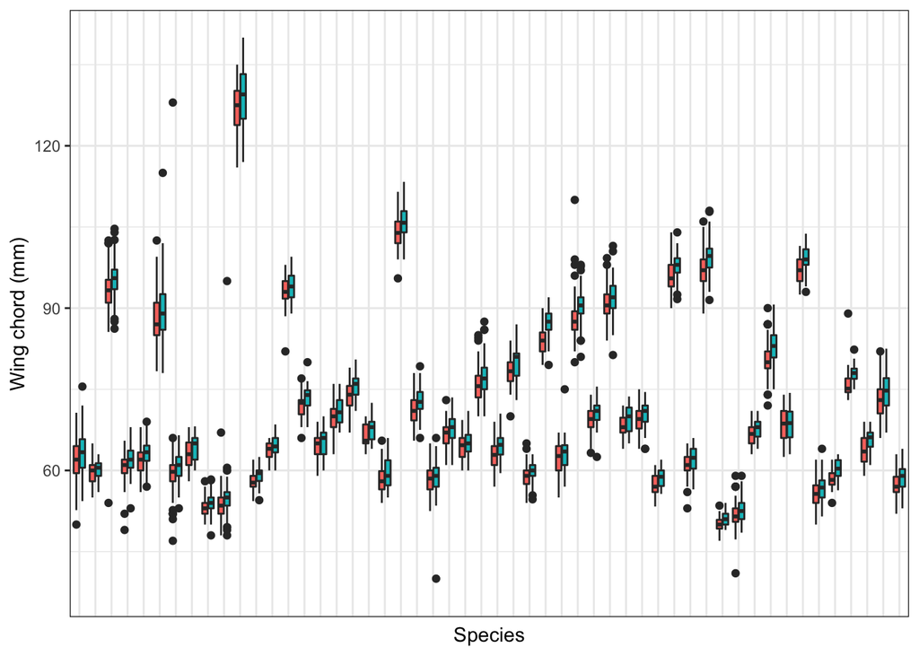

Figure 1: Boxplots for wing chord measurements for Age 1 (Second Year; RED) and Age 2+ (Third Year +; BLUE) birds for each species. Note that while the same individuals are shown in both groups, you can’t properly visualize the paired differences between the two time period for each individual in this way. There are likely better ways to visualize these data.